# cp2021-F07-Q03

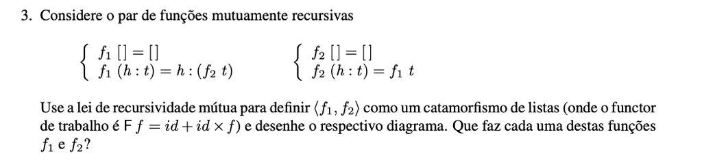

### Resolução

$\def\cata#1{\mathopen{(\!|}#1\mathclose{|\!)}}\def\kons#1{\underline{#1}}$

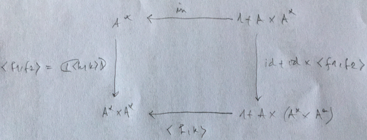

$<f1,f2> = \cata{<h,k>}$

{ **Fokkinga (lei da recursividade mútua)** }

$\equiv f1 . in = h . F <f1,f2> ; f1 . in = k . F <f1,f2>$

$f1 . in = h . (id + id \times <f1,f2>)$

$f2 . in = k . (id + id \times <f1,f2>)$

{ $in = [\kons{[]},cons]$; $h = [h1,h2]$; $k = [k1,k2]$ }

$f1 . [\kons{[]},cons] = [h1,h2] . (id + id \times <f1,f2>)$

$f2 . [\kons{[]},cons] = [k1,k2] . (id + id \times <f1,f2>)$

{ **fusão-$+$; absorção-$+$** }

$[f1 . \kons{[]}, f1 . cons] = [h1 . id, h2 . (id \times <f1,f2>)]$

$[f2 . \kons{[]}, f2 . cons] = [k1 . id, k2 . (id \times <f1,f2>)]$

{ **eq-$+$ ; natural-id** }

$f1 . \kons{[]} = h1$

$f1 . cons = h2 . (id \times <f1,f2>)$

$f2 . \kons{[]} = k1$

$f2 . cons = k2 . (id \times <f1,f2>)$

{ **def. f1: $h1 = \kons{[]}$; def f2: $k1 = \kons{[]}$** }

$f1 . \kons{[]} = \kons{[]}$

$f1 . cons = h2 . (id \times <f1,f2>)$

$f2 . \kons{[]} = \kons{[]}$

$f2 . cons = k2 . (id \times <f1,f2>)$

{ **def. f1: $h2 = cons . (id \times \pi_2)$; def f2: $k2 = \pi_1 . \pi_2$** }

$f1 . \kons{[]} = \kons{[]}$

$f1 . cons = cons . (id \times \pi_2) . (id \times <f1,f2>)$

$f2 . \kons{[]} = \kons{[]}$

$f2 . cons = \pi_1 . \pi_2 . (id \times <f1,f2>)$

Conclusão:

- $f1$ dá como resultado os elementos da sequência na posição impar;
- $f2$ dá como resultado os elementos da sequência na posição par.

```haskell
-- loading CP libs
:opt no-lint
:opt no-show-types
:load ../src/Cp.hs
:load ../src/Nat.hs
:load ../src/List.hs
:set -XNPlusKPatterns
```

```haskell
h1 = const []
h2 = cons . (id >< p2)
h = either h1 h2
k1 = const []
k2 = p1 . p2
k = either k1 k2
:t h
:t k
f = cataList (split (either h1 h2) (either k1 k2))
:t f

f [1,2,3,4]
```

h :: forall b a1 a2. Either b (a1, (a2, [a1])) -> [a1]

k :: forall b1 a1 a2 b2. Either b1 (a1, ([a2], b2)) -> [a2]

f :: forall a. [a] -> ([a], [a])

```
([1,3],[2,4])
```

```haskell
f1 [] = []
f1 (h:t) = h:(f2 t)
f2 [] = []
f2 (h:t) = f1 t

f1 [1,2,3,4,5]
f2 [1,2,3,4]
```

```
[1,3,5]
```

```
[2,4]
```